# Data Visualization Project 1 Infographic

Coffee Chain Comparison

Frank Marino Northeastern University INSH 5302: Information Design and Visual Analytics

February 08, 2026

# Introduction

Is Starbucks considered ‘luxury’ coffee?

Coffee brands often carry cultural meanings beyond the drinks they sell. Starbucks is frequently perceived as a more “premium” or “luxury” coffee brand, while Dunkin’ is often praised for its affordability and convince. This project explores whether those perceptions are reflected in the socioeconomic characteristics of the communities where these stores are located.

Using county-level data comparing Starbucks and Dunkin’ locations across 6 counties in Massachusetts, this analysis examines differences in median household income and store distribution. Visualizations including boxplots, bar charts, and summary tables are used to highlight income patterns and cost differences between the two brands. Together, these visuals help tell a data-driven story about how brand identity, geography, and economic context intersect in everyday consumer choices.

## Data

### Load Libraries and Packages

```r
rm(list = ls())
```

```r
require(moderndive)
require(dplyr)
require(tidyselect)
require(mosaic)
require(tibble)
require(sqldf)
require(tidyr)
require(ggpubr)
require(modeest)
DD_SB <- DD_vs_SB
```

### Description of data

> R Package: **moderndive**

> Data set: **DD_vs_SB**

### Load and Clean Data

```r
dd_sb_clean <- DD_SB %>%
  filter(
    shops >= 1,
    !is.na(median_income),
    !is.na(shop_type)
  )
dd_sb_clean <- dd_sb_clean %>%
  select(-FIPS)
```

Counties with missing income values or zero store counts were removed to ensure that all analyses reflected meaningful comparisons between existing Dunkin’ and Starbucks locations.

### Preview Data

```r
head(dd_sb_clean,10)
```

| county | median_income | population | shop_type | shops |
| --- | --- | --- | --- | --- |
| Bristol | 121607 | 5419 | starbucks | 1 |
| Bristol | 114769 | 3999 | dunkin_donuts | 1 |
| Bristol | 72042 | 5408 | dunkin_donuts | 1 |
| Bristol | 126840 | 5626 | dunkin_donuts | 2 |
| Bristol | 103542 | 6720 | dunkin_donuts | 1 |
| Bristol | 82361 | 3078 | dunkin_donuts | 1 |
| Bristol | 70308 | 6562 | dunkin_donuts | 2 |
| Bristol | 94340 | 4410 | dunkin_donuts | 4 |
| Bristol | 94340 | 4410 | starbucks | 1 |
| Bristol | 75967 | 9107 | dunkin_donuts | 2 |

### Variables

```r
names(dd_sb_clean)
```

```
## [1] "county"        "median_income" "population"    "shop_type"
## [5] "shops"
```

# Data Analysis

## Required Analysis

### Chart/Graph

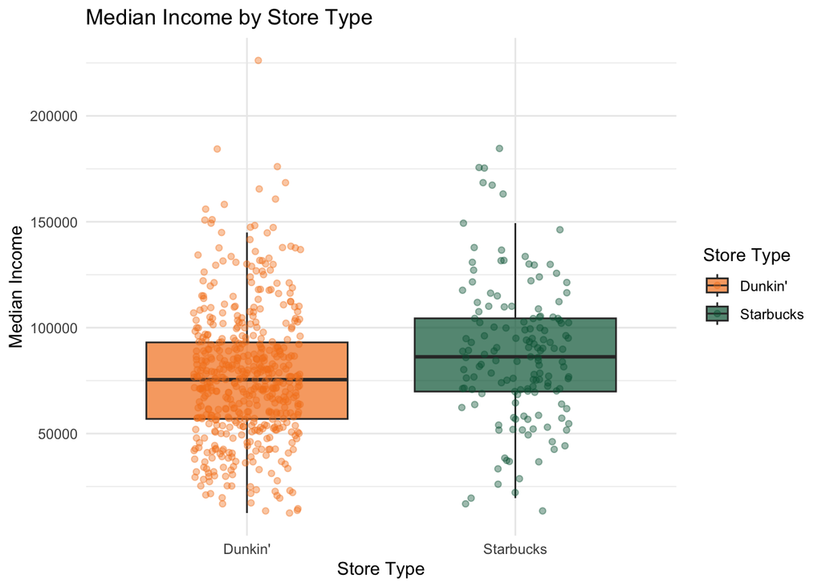

```r
library(ggplot2)
ggplot(dd_sb_clean, aes(x = shop_type, y = median_income, fill = shop_type)) +
  geom_boxplot(outlier.shape = NA, alpha = 0.7) +
  geom_jitter(aes(color = shop_type), width = 0.2, alpha = 0.4) +
  scale_fill_manual(
    values = c(
      "starbucks" = "#006241",
      "dunkin_donuts" = "#F5821F"
    ),
    labels = c(
      "starbucks" = "Starbucks",
      "dunkin_donuts" = "Dunkin'"
    ),
    name = "Store Type"
  ) +
  scale_color_manual(
    values = c(
      "starbucks" = "#006241",
      "dunkin_donuts" = "#F5821F"
    ),
    labels = c(
      "starbucks" = "Starbucks",
      "dunkin_donuts" = "Dunkin'"
    ),
    name = "Store Type"
  ) +
  scale_x_discrete(labels = c(
    "starbucks" = "Starbucks",
    "dunkin_donuts" = "Dunkin'"
  )) +
  labs(
    title = "Median Income by Store Type",
    x = "Store Type",
    y = "Median Income"
  ) +
  theme_minimal()
```

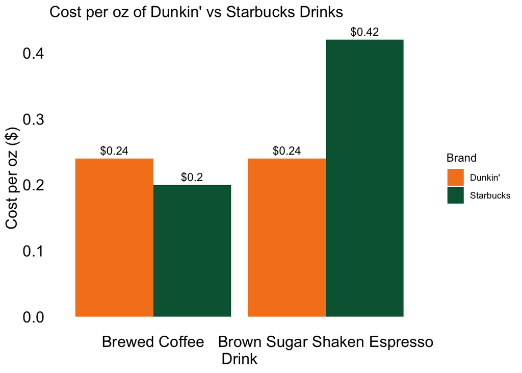

```r
cup_cost <- data.frame(
  Brand = c("Dunkin'", "Dunkin'", "Starbucks", "Starbucks"),
  Drink = c("Brewed Coffee", "Brown Sugar Shaken Espresso", "Brewed Coffee", "Brown Sugar Shaken Espresso"),
  Size = c(14, 24, 16, 16),
  Cost = c(3.39, 5.83, 3.19, 6.69), # Costs obtained from app ordering
  CostPerOz = c(0.24, 0.24, 0.20, 0.42) # Calculations
)

ggplot(cup_cost, aes(x = Drink, y = CostPerOz, fill = Brand)) +
  geom_bar(stat = "identity", position = "dodge") +
  geom_text(aes(label = paste0("$", CostPerOz)),
            vjust = -0.5, position = position_dodge(0.9), color = "black") +
  scale_fill_manual(values = c(
    "Starbucks" = "#006241",
    "Dunkin'" = "#F5821F"
  )) +
  labs(title = "Cost per oz of Dunkin' vs Starbucks Drinks",
       y = "Cost per oz ($)", x = "Drink") +
  theme_minimal() +
  theme(
    plot.background = element_rect(fill = "transparent", color = NA),
    panel.background = element_rect(fill = "transparent", color = NA),
    panel.grid = element_blank(),
    axis.text = element_text(color = "black", size = 15),
    axis.title = element_text(color = "black", size = 15),
    plot.title = element_text(color = "black", size = 15)
  ) #colors changed for export to canva
```

### Summary Statistics

```r
favstats(~median_income, data =dd_sb_clean)
```

|  | min | Q1 | median | Q3 | max | mean | sd | n | missing |
| --- | --- | --- | --- | --- | --- | --- | --- | --- | --- |
|  | 12490 | 57728.5 | 76890.5 | 96161 | 226181 | 79393.68 | 31616.78 | 654 | 0 |

```r
median_income_summary <- dd_sb_clean %>%
  summarise(
    n = n(),
    mean = mean(median_income, na.rm = TRUE),
    median = median(median_income, na.rm = TRUE),
    mode = mlv(median_income, method = "mfv")[1],  # pick first mode
    sd = sd(median_income, na.rm = TRUE),
    range = max(median_income, na.rm = TRUE) - min(median_income, na.rm = TRUE),
    min = min(median_income, na.rm = TRUE),
    max = max(median_income, na.rm = TRUE),
    Q1 = quantile(median_income, 0.25, na.rm = TRUE),
    Q3 = quantile(median_income, 0.75, na.rm = TRUE)
  )



median_income_by_store <- dd_sb_clean %>%
  group_by(shop_type) %>%
  summarise(
    n = n(),
    mean = mean(median_income, na.rm = TRUE),
    median = median(median_income, na.rm = TRUE),
    mode = mlv(median_income, method = "mfv")[1],  # pick first mode
    sd = sd(median_income, na.rm = TRUE),
    range = max(median_income, na.rm = TRUE) - min(median_income, na.rm = TRUE),
    min = min(median_income, na.rm = TRUE),
    max = max(median_income, na.rm = TRUE),
    Q1 = quantile(median_income, 0.25, na.rm = TRUE),
    Q3 = quantile(median_income, 0.75, na.rm = TRUE)
  ) %>%
  mutate(shop_type = case_when(
    shop_type == "dunkin_donuts" ~ "Dunkin'",
    shop_type == "starbucks" ~ "Starbucks"
  ))
  table_plot <- ggtexttable(median_income_by_store,
                          rows = NULL,
                          theme = ttheme(
                            "light",
                            base_size = 12,
                            colnames.style = colnames_style(
                              fill = "grey90",
                              color = "black",
                              face = "bold"
                            ),
                            tbody.style = tbody_style(
                              fill = c("#F5821F", "#006241"),  # Dunkin/Starbucks row colors
                              color = "white"
                            )
                          )) # Kind of ugly, maybe won't include
```

## Additional Analyses

```r
wilcox.test(median_income ~ shop_type, data = dd_sb_clean)
```

```
##
##  Wilcoxon rank sum test with continuity correction
##
## data:  median_income by shop_type
## W = 29812, p-value = 0.0001162
## alternative hypothesis: true location shift is not equal to 0
```

```r
tapply(dd_sb_clean$median_income, dd_sb_clean$shop_type, median)
```

```
## dunkin_donuts     starbucks
##         75461         86250
```

A Wilcoxon rank-sum test revealed a statistically significant difference in local median income between Starbucks and Dunkin locations (W = 29,812, p = 0.00012). Starbucks locations were situated in areas with higher median income (median = $86,250) compared to Dunkin locations (median = $75,461).

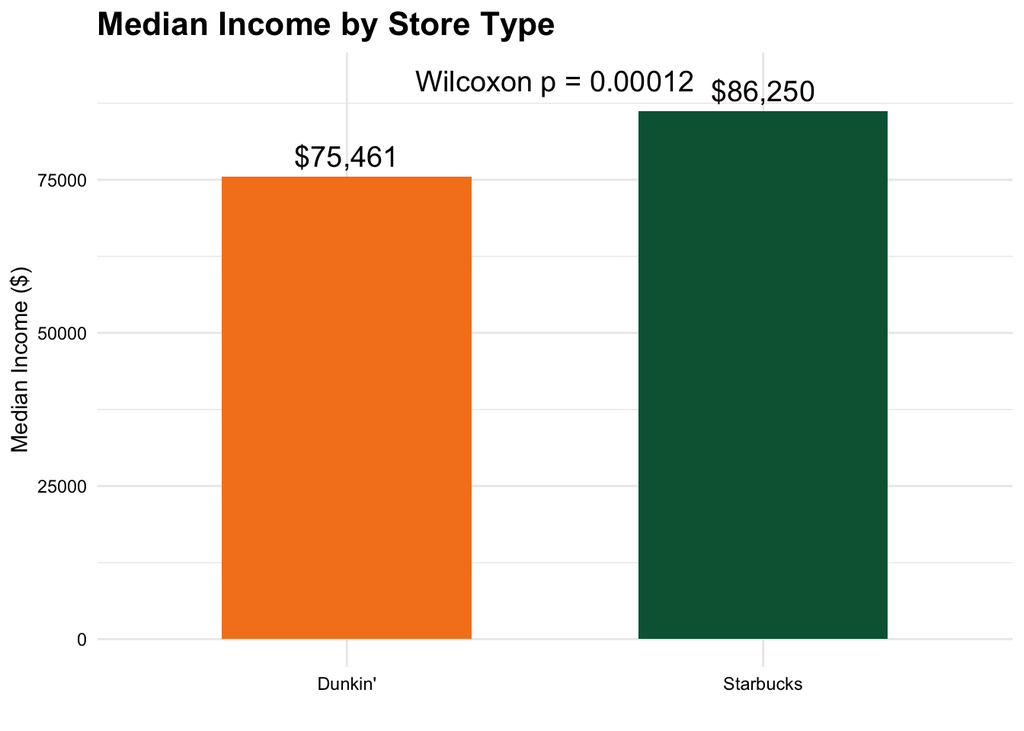

```r
median_df <- dd_sb_clean %>%
  group_by(shop_type) %>%
  summarise(MedianIncome = median(median_income, na.rm = TRUE))

# Bar plot with median labels and p-value
ggplot(median_df, aes(x = shop_type, y = MedianIncome, fill = shop_type)) +
  geom_col(width = 0.6) +
  geom_text(aes(label = paste0("$", format(MedianIncome, big.mark=","))),
            vjust = -.5, color = "black", size = 5) +
  annotate("text", x = 1.5, y = max(median_df$MedianIncome) + 5000,
           label = "Wilcoxon p = 0.00012", size = 5, color = "black") +
  scale_fill_manual(
    values = c(
      "starbucks" = "#006241",
      "dunkin_donuts" = "#F5821F"
    ),
    labels = c(
      "starbucks" = "Starbucks",
      "dunkin_donuts" = "Dunkin'"
    ),
    name = "Store Type"
  ) +
  scale_x_discrete(labels = c(
    "starbucks" = "Starbucks",
    "dunkin_donuts" = "Dunkin'"
  )) +
  labs(
    title = "Median Income by Store Type",
    x = "",
    y = "Median Income ($)"
  ) +
  theme_minimal() +
  theme(
    plot.background = element_rect(fill = "transparent", color = NA),
    panel.background = element_rect(fill = "transparent", color = NA),
    axis.text = element_text(color = "black"),
    axis.title = element_text(color = "black"),
    plot.title = element_text(color = "black", face = "bold", size = 16),
    legend.position = "none"
  )
```

```r
# colors were changed to white for canva presentation.
```

```r
sum_dunk <- sum(dd_sb_clean$shops[dd_sb_clean$shop_type == "dunkin_donuts"])
sum_star <- sum(dd_sb_clean$shops[dd_sb_clean$shop_type == "starbucks"])
```

```r
store_counts <- dd_sb_clean %>%
  group_by(county, shop_type) %>%
  summarise(TotalShops = sum(shops, na.rm = TRUE)) %>%
  pivot_wider(names_from = shop_type, values_from = TotalShops, values_fill = 0) %>%
  arrange(county)
```

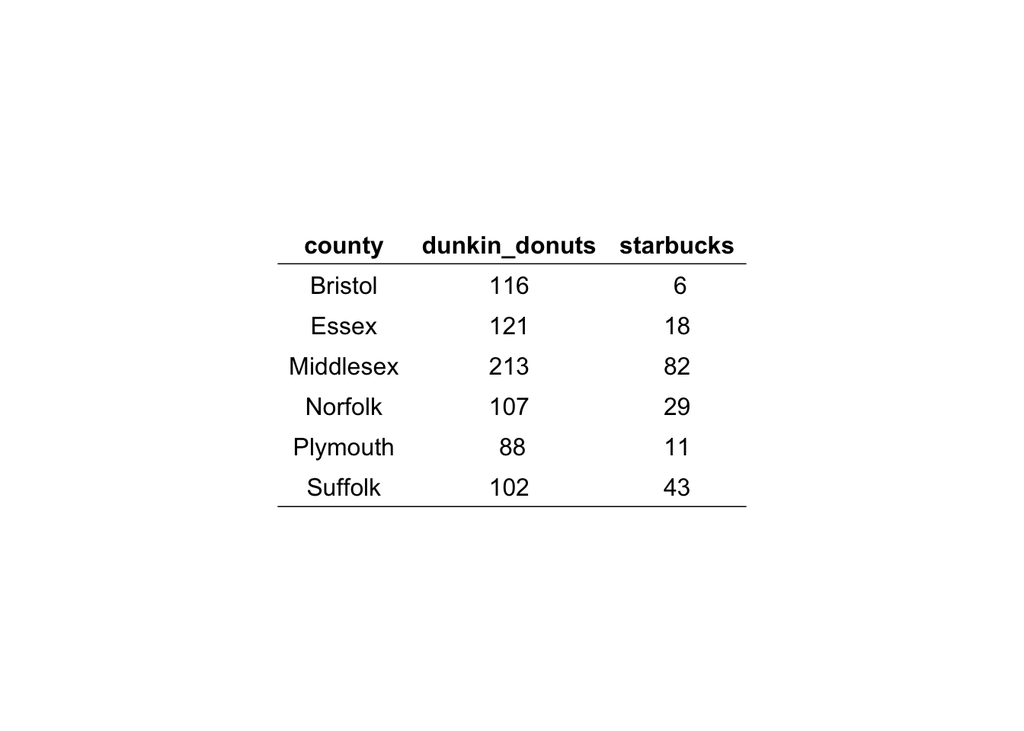

```r
table_plot <- ggtexttable(store_counts,
                          rows = NULL,
                          theme = ttheme("light", base_size = 12))
table_plot
```

# Infographic

[interactive chart not shown]

[Starbucks](https://www.canva.com/design/DAHAYc_6Pxo/_9Hdx7aNaCGajV_rWfmu2Q/view?utm_content=DAHAYc_6Pxo&utm_campaign=designshare&utm_medium=embeds&utm_source=link) by Frank Marino

URL Link to Canva Site: [Frank Marino - Data Viz Project 1](https://www.canva.com/design/DAHAYc_6Pxo/_9Hdx7aNaCGajV_rWfmu2Q/view)

# References

1. moderndive: Statistical Inference via Data Science.
2. Dunkin’ and Starbucks mobile ordering applications (pricing data).
3. https://www.starbucks.com/responsibility/sourcing/coffee/

# All done!

Knit the completed R Markdown file as a HTML document (click the “Knit” button at the top of the script editor window) and upload it to the submission portal on Canvas.